# examples_0318

Consider the string of characters shown below:

`FWGXQMYXL`

What new string would be created if every instance of `X` was replaced with `FZ`?

(Please use all uppercase letters and NO spaces.)

Here is the answer:

FWGFZQMYFZL

Notice, every `X` is now `FZ`.

Consider the string of characters shown below:

`SKSZUYWNS`

What new string would be created if every instance of `S` was replaced with `IG`?

(Please use all uppercase letters and NO spaces.)

Here is the answer:

IGKIGZUYWNIG

Notice, every `S` is now `IG`.

Consider the string of characters shown below:

`TTTXSIVTP`

What new string would be created if every instance of `T` was replaced with `YV`?

(Please use all uppercase letters and NO spaces.)

Here is the answer:

YVYVYVXSIVYVP

Notice, every `T` is now `YV`.

Consider the string of characters shown below:

`AGHFFQF`

What new string would be created if every instance of `F` was replaced with `ID`?

(Please use all uppercase letters and NO spaces.)

Here is the answer:

AGHIDIDQID

Notice, every `F` is now `ID`.

Consider the string of characters shown below:

`RYYTTN`

What new string would be created if every instance of `T` was replaced with `BL`?

(Please use all uppercase letters and NO spaces.)

Here is the answer:

RYYBLBLN

Notice, every `T` is now `BL`.

Consider the string of characters shown below:

`VBMBYBF`

What new string would be created if every instance of `B` was replaced with `GP`?

(Please use all uppercase letters and NO spaces.)

Here is the answer:

VGPMGPYGPF

Notice, every `B` is now `GP`.

Consider the string of characters shown below:

`BASGANB`

What new string would be created if every instance of `A` was replaced with `ZP`?

(Please use all uppercase letters and NO spaces.)

Here is the answer:

BZPSGZPNB

Notice, every `A` is now `ZP`.

Consider the string of characters shown below:

`MVSZDVKVF`

What new string would be created if every instance of `V` was replaced with `CM`?

(Please use all uppercase letters and NO spaces.)

Here is the answer:

MCMSZDCMKCMF

Notice, every `V` is now `CM`.

Consider the string of characters shown below:

`MMBCIGIGG`

What new string would be created if every instance of `I` was replaced with `QK`?

(Please use all uppercase letters and NO spaces.)

Here is the answer:

MMBCQKGQKGG

Notice, every `I` is now `QK`.

Consider the string of characters shown below:

`FSVFGXYHG`

What new string would be created if every instance of `G` was replaced with `QV`?

(Please use all uppercase letters and NO spaces.)

Here is the answer:

FSVFQVXYHQV

Notice, every `G` is now `QV`.

A turtle starts at the star in the middle, facing North. While dragging markers, she walks forward for a while, then turns either to her right (clockwise) or to her left (counterclockwise) by 90°. She repeats this, starting with a red marker, until she has drawn 4 segments.

The distance between adjacent dots is 1 unit.

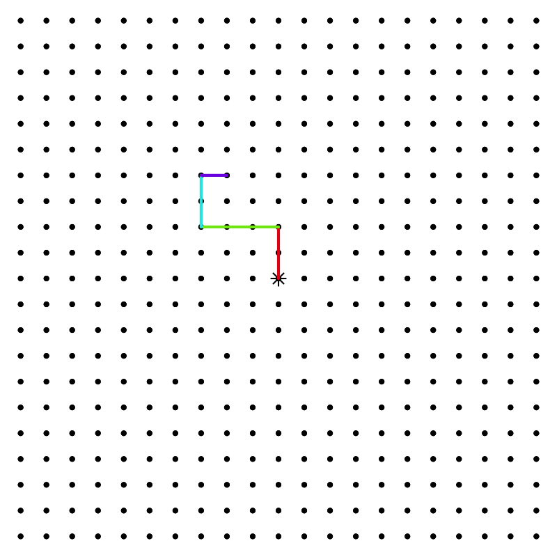

Describe the path taken by the turtle by typing a string of characters.

- Character `F` means go forward 1 unit.
- Character `+` means turn right (clockwise) 90°.
- Character `-` means turn left (counterclockwise) 90°.

Remember to use uppercase `F` and no spaces.

The path could be described as...

- Go 2
- Turn left
- Go 3
- Turn right
- Go 2
- Turn right
- Go 1

So, using those characters...

`FF-FFF+FF+F`

A turtle starts at the star in the middle, facing North. While dragging markers, she walks forward for a while, then turns either to her right (clockwise) or to her left (counterclockwise) by 90°. She repeats this, starting with a red marker, until she has drawn 4 segments.

The distance between adjacent dots is 1 unit.

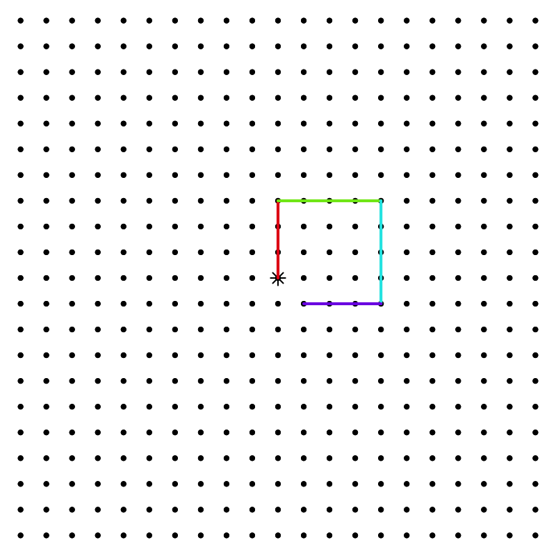

Describe the path taken by the turtle by typing a string of characters.

- Character `F` means go forward 1 unit.
- Character `+` means turn right (clockwise) 90°.
- Character `-` means turn left (counterclockwise) 90°.

Remember to use uppercase `F` and no spaces.

The path could be described as...

- Go 3
- Turn right
- Go 4
- Turn right
- Go 4
- Turn right
- Go 3

So, using those characters...

`FFF+FFFF+FFFF+FFF`

A turtle starts at the star in the middle, facing North. While dragging markers, she walks forward for a while, then turns either to her right (clockwise) or to her left (counterclockwise) by 90°. She repeats this, starting with a red marker, until she has drawn 4 segments.

The distance between adjacent dots is 1 unit.

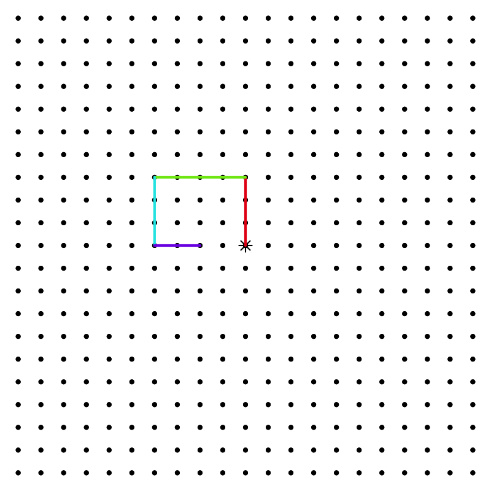

Describe the path taken by the turtle by typing a string of characters.

- Character `F` means go forward 1 unit.
- Character `+` means turn right (clockwise) 90°.
- Character `-` means turn left (counterclockwise) 90°.

Remember to use uppercase `F` and no spaces.

The path could be described as...

- Go 3
- Turn left
- Go 4
- Turn left
- Go 3
- Turn left
- Go 2

So, using those characters...

`FFF-FFFF-FFF-FF`

A turtle starts at the star in the middle, facing North. While dragging markers, she walks forward for a while, then turns either to her right (clockwise) or to her left (counterclockwise) by 90°. She repeats this, starting with a red marker, until she has drawn 4 segments.

The distance between adjacent dots is 1 unit.

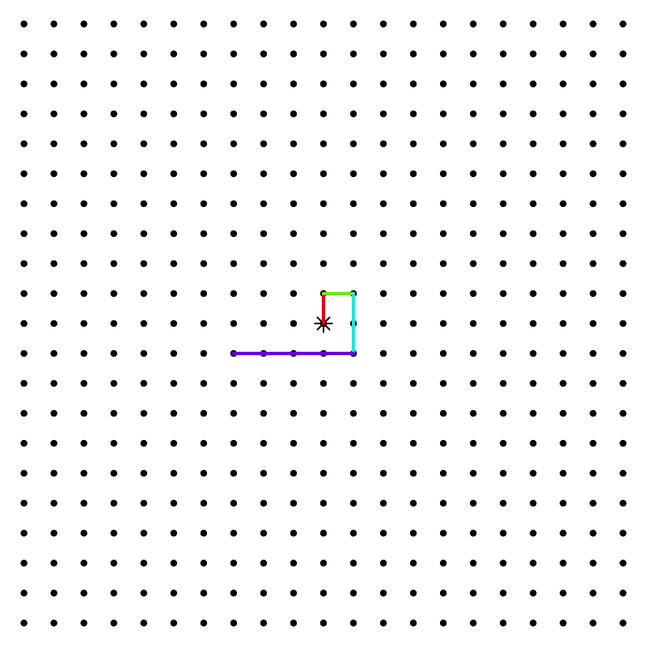

Describe the path taken by the turtle by typing a string of characters.

- Character `F` means go forward 1 unit.
- Character `+` means turn right (clockwise) 90°.
- Character `-` means turn left (counterclockwise) 90°.

Remember to use uppercase `F` and no spaces.

The path could be described as...

- Go 1
- Turn right
- Go 1
- Turn right
- Go 2
- Turn right
- Go 4

So, using those characters...

`F+F+FF+FFFF`

A turtle starts at the star in the middle, facing North. While dragging markers, she walks forward for a while, then turns either to her right (clockwise) or to her left (counterclockwise) by 90°. She repeats this, starting with a red marker, until she has drawn 4 segments.

The distance between adjacent dots is 1 unit.

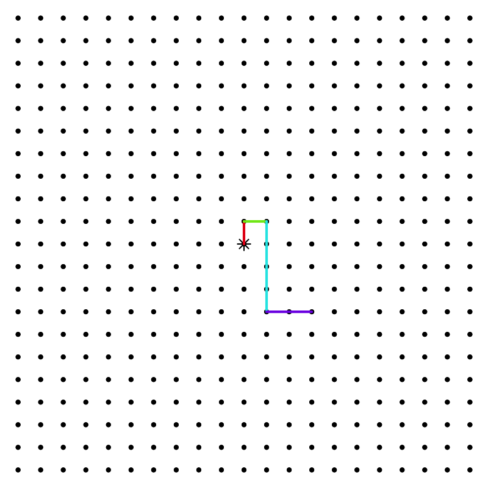

Describe the path taken by the turtle by typing a string of characters.

- Character `F` means go forward 1 unit.
- Character `+` means turn right (clockwise) 90°.
- Character `-` means turn left (counterclockwise) 90°.

Remember to use uppercase `F` and no spaces.

The path could be described as...

- Go 1
- Turn right
- Go 1
- Turn right
- Go 4
- Turn left
- Go 2

So, using those characters...

`F+F+FFFF-FF`

A turtle starts at the star in the middle, facing North. While dragging markers, she walks forward for a while, then turns either to her right (clockwise) or to her left (counterclockwise) by 90°. She repeats this, starting with a red marker, until she has drawn 4 segments.

The distance between adjacent dots is 1 unit.

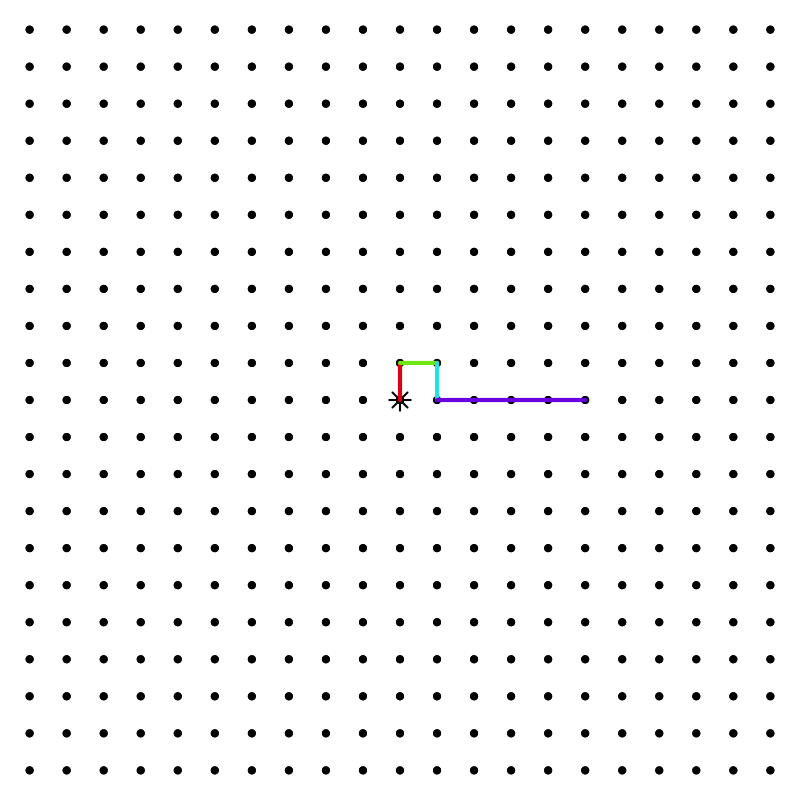

Describe the path taken by the turtle by typing a string of characters.

- Character `F` means go forward 1 unit.
- Character `+` means turn right (clockwise) 90°.
- Character `-` means turn left (counterclockwise) 90°.

Remember to use uppercase `F` and no spaces.

The path could be described as...

- Go 1
- Turn right
- Go 1
- Turn right
- Go 1
- Turn left
- Go 4

So, using those characters...

`F+F+F-FFFF`

A turtle starts at the star in the middle, facing North. While dragging markers, she walks forward for a while, then turns either to her right (clockwise) or to her left (counterclockwise) by 90°. She repeats this, starting with a red marker, until she has drawn 4 segments.

The distance between adjacent dots is 1 unit.

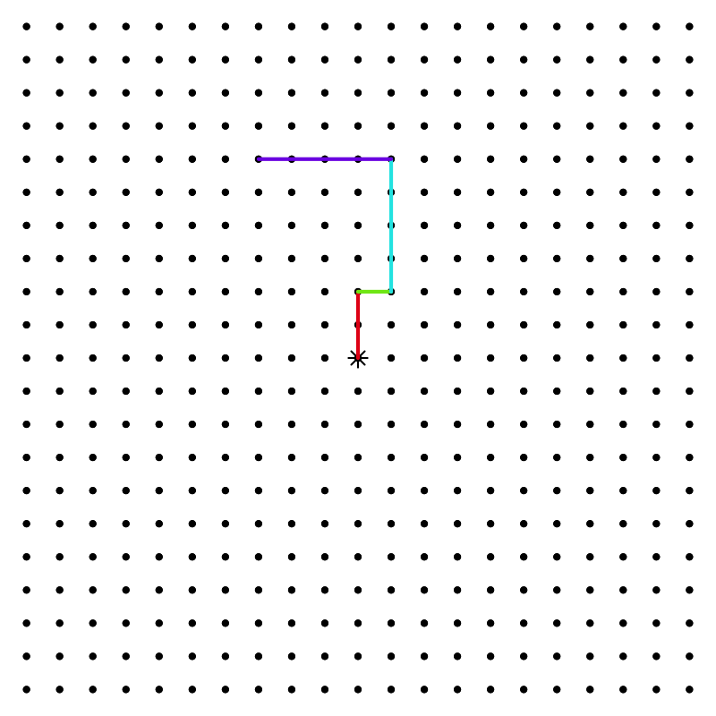

Describe the path taken by the turtle by typing a string of characters.

- Character `F` means go forward 1 unit.
- Character `+` means turn right (clockwise) 90°.
- Character `-` means turn left (counterclockwise) 90°.

Remember to use uppercase `F` and no spaces.

The path could be described as...

- Go 2
- Turn right
- Go 1
- Turn left
- Go 4
- Turn left
- Go 4

So, using those characters...

`FF+F-FFFF-FFFF`

A turtle starts at the star in the middle, facing North. While dragging markers, she walks forward for a while, then turns either to her right (clockwise) or to her left (counterclockwise) by 90°. She repeats this, starting with a red marker, until she has drawn 4 segments.

The distance between adjacent dots is 1 unit.

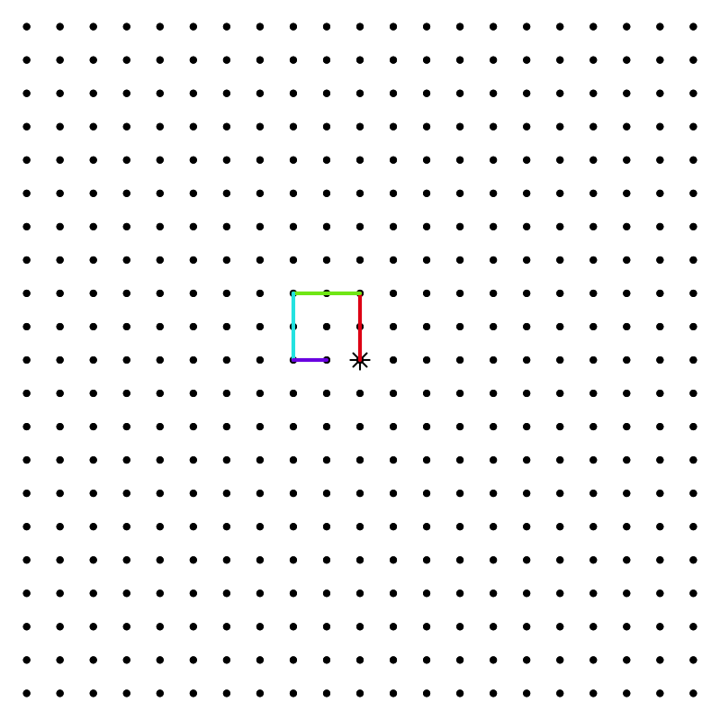

Describe the path taken by the turtle by typing a string of characters.

- Character `F` means go forward 1 unit.
- Character `+` means turn right (clockwise) 90°.
- Character `-` means turn left (counterclockwise) 90°.

Remember to use uppercase `F` and no spaces.

The path could be described as...

- Go 2
- Turn left
- Go 2
- Turn left
- Go 2
- Turn left
- Go 1

So, using those characters...

`FF-FF-FF-F`

A turtle starts at the star in the middle, facing North. While dragging markers, she walks forward for a while, then turns either to her right (clockwise) or to her left (counterclockwise) by 90°. She repeats this, starting with a red marker, until she has drawn 4 segments.

The distance between adjacent dots is 1 unit.

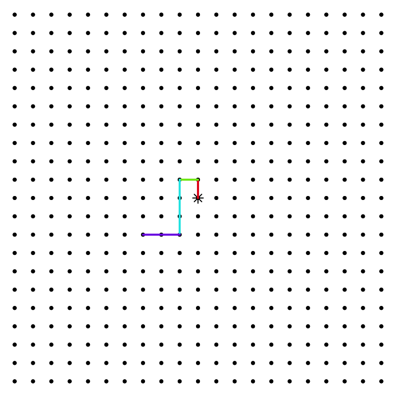

Describe the path taken by the turtle by typing a string of characters.

- Character `F` means go forward 1 unit.
- Character `+` means turn right (clockwise) 90°.
- Character `-` means turn left (counterclockwise) 90°.

Remember to use uppercase `F` and no spaces.

The path could be described as...

- Go 1
- Turn left
- Go 1
- Turn left
- Go 3
- Turn right
- Go 2

So, using those characters...

`F-F-FFF+FF`

A turtle starts at the star in the middle, facing North. While dragging markers, she walks forward for a while, then turns either to her right (clockwise) or to her left (counterclockwise) by 90°. She repeats this, starting with a red marker, until she has drawn 4 segments.

The distance between adjacent dots is 1 unit.

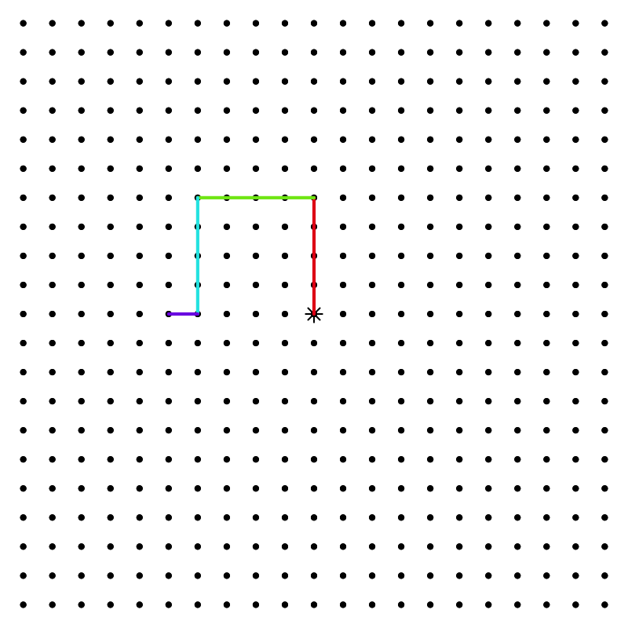

Describe the path taken by the turtle by typing a string of characters.

- Character `F` means go forward 1 unit.
- Character `+` means turn right (clockwise) 90°.
- Character `-` means turn left (counterclockwise) 90°.

Remember to use uppercase `F` and no spaces.

The path could be described as...

- Go 4
- Turn left
- Go 4
- Turn left
- Go 4
- Turn right
- Go 1

So, using those characters...

`FFFF-FFFF-FFFF+F`